# Predicting Who Would Subscribe for a Term Deposit in a Bank

## Introduction

### Dataset Source

The dataset used for this project was sourced from the UCI Machine Learning Repository (Bank Marketing Data Set, 2014). The information contained in the dataset is about the clients of a Portuguese Bank, dated from May 2008 to November 2010.

### Dataset Details

The dataset is about the clienteles of a Portuguese Bank. The campaigns held by the bank used phone calls as the mode of converting their normal client into a term deposit client. The folder contains various datasets, but for the purpose of this project we would be using the bank-additional-full.csv file as it contains the complete record of all the leads attained by the bank. The other datasets are a subset of this dataset (Bank Marketing Data Set, 2014).

The dataset in use contains 41188 instances with 21 total attributes (including the target feature 'variable `y`'). The information contained about the clients includes: age, job, marital status, education, has the client defaulted in credit, and whether the client has housing loan (UCI Machine Learning Repository, 2014).

Additional information: type of contact to the client (telephone or cellular), last month of contact, last contact day of week, the duration of the last call, number of campaigns performed on a particular client, days since the client was last contacted, number of calls performed before this campaign, previous campaign outcome, and other social and economic context attributes such as Employment variation rate (quarterly), Consumer Price Index (monthly), Consumer Confidence Index (monthly), EURIOBOR 3 month rate (daily), and number of employees (quarterly) (UCI Machine Learning Repository, 2014).

The definitions of certain terms have been provided below for attaining a better context to the problem at hand.

**Term Deposit**: It is a fixed-term investment by a customer that involves the deposit of money into an account in a financial institution.(Investopedia, 2022).

**The Consumer Price Index (CPI)**: It is a type of measurement system that intends to examine the weighted prices of goods. Any deviation in the CPI would affect the cost of living for the people in a country (Investopedia, 2022).

**The Consumer Confidence Index (CCI)**: It takes into consideration how positive the consumers are about spending on goods. It is a directly proportional relationship i.e. more amount of spending by the consumer would result in benefiting the society (Investopedia, 2022).

#### Dataset Retrieval

1. The data folder is a .zip file, hence before reading we extract the file, and then load into this jupyter notebook. Since the file is stored locally on this machine we can just import it. Before doing so, we will load the required modules that will necessary throughout this report.
2. We will also display 10 randomly sampled observations from the dataset (to check if everything is in order before we proceed further).

```python
#Loading the various packages and modules that will be needed for this report
import warnings
warnings.filterwarnings("ignore")

import numpy as np
import pandas as pd
import matplotlib.pyplot as plt
import seaborn as sns

pd.set_option('display.max_columns', None) #Displays all columns in the dataset while printing

%matplotlib inline
%config InlineBackend.figure_format ='retina'
plt.style.use('seaborn')
```

```python
# Reading the bank-additional-full.csv file

clients = pd.read_csv("bank-additional-full.csv", sep = ';', encoding = 'utf8')
```

Since the file has been read into memory, we can display observations from it (as shown below).

```python
# Check to see if the dataset has been imported, displaying a random sample.
# The random_state argument assures that the output remains same irrespective of the times the code is run.

clients.sample(10, random_state=999).round(3)
```

|  | age | job | marital | education | default | housing | loan | contact | month | day_of_week | duration | campaign | pdays | previous | poutcome | emp.var.rate | cons.price.idx | cons.conf.idx | euribor3m | nr.employed | y |
| --- | --- | --- | --- | --- | --- | --- | --- | --- | --- | --- | --- | --- | --- | --- | --- | --- | --- | --- | --- | --- | --- |
| 30370 | 59 | admin. | married | high.school | no | yes | no | cellular | apr | thu | 147 | 3 | 999 | 1 | failure | -1.8 | 93.075 | -47.1 | 1.365 | 5099.1 | no |
| 34765 | 38 | technician | single | professional.course | no | yes | no | cellular | may | thu | 306 | 4 | 999 | 0 | nonexistent | -1.8 | 92.893 | -46.2 | 1.266 | 5099.1 | no |
| 14618 | 39 | admin. | divorced | high.school | no | yes | no | cellular | jul | tue | 514 | 5 | 999 | 0 | nonexistent | 1.4 | 93.918 | -42.7 | 4.961 | 5228.1 | yes |
| 5673 | 31 | blue-collar | married | basic.6y | unknown | yes | yes | telephone | may | mon | 161 | 1 | 999 | 0 | nonexistent | 1.1 | 93.994 | -36.4 | 4.857 | 5191.0 | no |
| 37545 | 70 | retired | married | professional.course | no | no | no | cellular | aug | fri | 185 | 3 | 999 | 1 | failure | -2.9 | 92.201 | -31.4 | 0.869 | 5076.2 | no |
| 22715 | 51 | services | married | unknown | no | no | yes | cellular | aug | fri | 135 | 3 | 999 | 0 | nonexistent | 1.4 | 93.444 | -36.1 | 4.964 | 5228.1 | no |
| 32146 | 39 | blue-collar | divorced | basic.9y | no | yes | no | cellular | may | fri | 191 | 1 | 999 | 0 | nonexistent | -1.8 | 92.893 | -46.2 | 1.313 | 5099.1 | no |
| 20213 | 45 | admin. | married | university.degree | no | no | no | cellular | aug | mon | 608 | 1 | 999 | 0 | nonexistent | 1.4 | 93.444 | -36.1 | 4.965 | 5228.1 | yes |
| 20455 | 36 | technician | single | university.degree | unknown | no | no | cellular | aug | tue | 73 | 1 | 999 | 0 | nonexistent | 1.4 | 93.444 | -36.1 | 4.966 | 5228.1 | no |
| 32998 | 40 | services | married | high.school | unknown | yes | no | cellular | may | mon | 182 | 5 | 999 | 0 | nonexistent | -1.8 | 92.893 | -46.2 | 1.299 | 5099.1 | no |

As we can see the `clients` dataset has been imported correctly, and displays all the columns (21) including the target feature `y`. An observation that can be made at this point is that there is no ID based column, and we can see certain attributes with values `unknown` and `999`. The details of these are provided in the section below.

### Dataset Features

Before we begin with the exploration of the data, let us describe all the features of the dataset in a tabular form below. Please note that these details have been sourced from the file **bank-additional-names.names** file present within the same data folder retrieved from the UCI Machine Learning Repository (UCI Machine Learning Repository, 2014).

| S.No | Feature Name | Data-Type | Units | Description | Domain |
| --- | --- | --- | --- | --- | --- |
| 1 | Age | Numeric | Not Applicable | Age of the client | - |
| 2 | Job | Categorical | Not Applicable | Type of job the client does | Admin, Blue-Collar, Entreprenuer, Housemaid, Management, Retired, Self-Employed, Services, Student, Technician, Unemployed, and Unknown |
| 3 | Marital | Categorical | Not Applicable | Marital Status of the Client | Divorced (means divorced or widowed), Married, Single, Unknown |
| 4 | Education | Categorical | Not Applicable | Education of the client | Basic.4y,Basic.6y,Basic.9y,High.School,Illiterate,Professional.course,University.degree, and Unknown |
| 5 | Default | Categorical | Not Applicable | If the client has defaulted in credit | No,Yes, Unknown |
| 6 | Housing | Categorical | Not Applicable | If the client has a housing loan | No,Yes, Unknown |
| 7 | Loan | Categorical | Not Applicable | If the client has a personal loan | No,Yes, Unknown |
| 8 | Contact | Categorical | Not Applicable | Contact Communication type | Cellular or Telephone |
| 9 | Month | Categorical | Not Applicable | Last contact month of the year | Jan, Feb...till..Dec |
| 10 | Day_of_Week | Categorical | Not Applicable | Last contact day of the week | Mon, Tue, Wed, Thu, Fri |
| 11 | Duration | Numeric | Seconds | Last contact duration | - |
| 12 | Campaign | Numeric | Not Applicable | Number of contacts performed during this campaign and for this client | **Includes Last Contact** |
| 13 | PDays | Numeric | Days | Number of days that passed by after the client was last contacted from a previous campaign | **999 - Client was not previously contacted** |
| 14 | Previous | Numeric | Not Applicable | Number of contacts performed before this campaign and for this client | - |
| 15 | Poutcome | Categorical | Not Applicable | Outcome of the previous marketing campaign | Failure, Nonexistent, Success |
| 16 | emp.var.rate | Numeric | Not Applicable | Employement variation rate | - |
| 17 | cons.price.idx | Numeric | Not Applicable | Consumer Price Index | - |
| 18 | cons.conf.idx | Numeric | Not Applicable | Consumer Confidence Index | - |
| 19 | euribor3m | Numeric | Expressed as Percentage | Rate of deposits in Euros for a period of 3 months | - |
| 20 | nr.employed | Numeric | Thousands | Number of employed citizens | - |
| 21 | y | Binary | Not Applicable | Has the client subscribed a term deposit | Yes, No |

### Target Feature

For this project, the target feature is the '**variable `y`**' (categorical), which is a binary attribute, `yes` means the client subscribed for a term deposit, and `no` means the client rejected the offer. The outcome of the target feature will be predicted (in phase-2) using the descriptive features that we have in hand.

## Goals and Objectives

A marketing campaign is performed either to get new leads or to convert a lead into a customer. Any banking institution that can predict to a certain accuracy who might become their valuable client will help cut down costs, and in turn use those finances for other services.

A term deposit sign-up by a customer means that the bank now has more cash flow coming in, which would in-turn be used to provide loans. A customer gets the benefit of receiving interest on his/ her investment, the time-period of which is decided by the bank.

**Note: The observations in this dataset are not correlated.**

## Data Cleaning and Preprocessing

This section is necessary for preparing the data for further exploration (in the upcoming sections), and it involves the following tasks:

1. Checking for missing values
2. Checking for features with one constant value
3. Removing duplicate observations
4. Dropping any irrelevant or redundant attributes
5. Checking for any wrong values
6. Appropriately renaming columns (if any).

### Confirmation of details about the dataset

Before we begin with the above steps, let us initially gather some information about the dataset at hand, and confirm properties such as data-type, shape, and column names.

```python
# To find the dimensions of the dataframe
clients.shape
```

```
(41188, 21)
```

The above output tells us that there are 41188 rows and 21 columns which is correct to the information provided by the data-source as well.

```python
# To check the names of all the columns
clients.columns
```

```
Index(['age', 'job', 'marital', 'education', 'default', 'housing', 'loan',
       'contact', 'month', 'day_of_week', 'duration', 'campaign', 'pdays',
       'previous', 'poutcome', 'emp.var.rate', 'cons.price.idx',
       'cons.conf.idx', 'euribor3m', 'nr.employed', 'y'],
      dtype='object')
```

As we can see that almost all the columns are well defined by their names except column named `marital`, and the target feature `y`, we will rename them in the following sub-sections.

```python
# To check data-types of the features
clients.dtypes
```

```
age                 int64
job                object
marital            object
education          object
default            object
housing            object
loan               object
contact            object
month              object
day_of_week        object
duration            int64
campaign            int64
pdays               int64
previous            int64
poutcome           object
emp.var.rate      float64
cons.price.idx    float64
cons.conf.idx     float64
euribor3m         float64
nr.employed       float64
y                  object
dtype: object
```

We can observe from the above output that the data-types are accurately conveyed by the source, and there is no need for any type conversion.

### 1. Checking for Missing Values

The first step of Data Cleaning process is to eliminate any missing values from the dataset. The following line of code checks if there are any missing values.

```python
# To check for missing values

clients.isnull().sum()
```

```
age               0
job               0
marital           0
education         0
default           0
housing           0
loan              0
contact           0
month             0
day_of_week       0
duration          0
campaign          0
pdays             0
previous          0
poutcome          0
emp.var.rate      0
cons.price.idx    0
cons.conf.idx     0
euribor3m         0
nr.employed       0
y                 0
dtype: int64
```

The above line of code uses two functions `isnull()` which is a boolean function checks for any column with `NA` or `Null` as input, and `sum()` which basically returns the sum of the boolean values for each attribute.

The above output depicts that there are no missing values but we know from feature description that features such as job, marital, education, housing, loan and default have an input value `unknown` (because the client did not reveal the details citing personal reasons) which in context is just like any other missing value.

To find the contribution or the effect of these observations on the overall dataset we will explore the unique values for each feature, and percentage of these `unknown` observations.

```python
# To check for values in certain features

unknowns_col = ['education','housing','loan','marital','default','job']

for col in unknowns_col:
    print(f'All domain values of {col} are:')
    print(clients[col].value_counts())
    print('\n')
```

```
All domain values of education are:
university.degree      12168
high.school             9515
basic.9y                6045
professional.course     5243
basic.4y                4176
basic.6y                2292
unknown                 1731
illiterate                18
Name: education, dtype: int64


All domain values of housing are:
yes        21576
no         18622
unknown      990
Name: housing, dtype: int64


All domain values of loan are:
no         33950
yes         6248
unknown      990
Name: loan, dtype: int64


All domain values of marital are:
married     24928
single      11568
divorced     4612
unknown        80
Name: marital, dtype: int64


All domain values of default are:
no         32588
unknown     8597
yes            3
Name: default, dtype: int64


All domain values of job are:
admin.           10422
blue-collar       9254
technician        6743
services          3969
management        2924
retired           1720
entrepreneur      1456
self-employed     1421
housemaid         1060
unemployed        1014
student            875
unknown            330
Name: job, dtype: int64
```

From the above output, we can see that for features `education`, `housing`, `loan`, `job`, `marital`, and `default`; **unknown** has 1731, 990, 990, 330, 80, and 8597 values respectively, a total of 12,718. But this does not give us the exact picture, as an observation may have multiple unknowns for different features.

To better understand the statistics of `unknown`, let us calculate its percentage of contribution.

```python
for col in unknowns_col:
    print(f'All domain values of {col} are:')
    print(clients[col].value_counts(normalize=True).mul(100).round(3))
    print('\n')
```

```
All domain values of education are:
university.degree      29.543
high.school            23.101
basic.9y               14.677
professional.course    12.729
basic.4y               10.139
basic.6y                5.565
unknown                 4.203
illiterate              0.044
Name: education, dtype: float64


All domain values of housing are:
yes        52.384
no         45.212
unknown     2.404
Name: housing, dtype: float64


All domain values of loan are:
no         82.427
yes        15.169
unknown     2.404
Name: loan, dtype: float64


All domain values of marital are:
married     60.522
single      28.086
divorced    11.197
unknown      0.194
Name: marital, dtype: float64


All domain values of default are:
no         79.120
unknown    20.873
yes         0.007
Name: default, dtype: float64


All domain values of job are:
admin.           25.303
blue-collar      22.468
technician       16.371
services          9.636
management        7.099
retired           4.176
entrepreneur      3.535
self-employed     3.450
housemaid         2.574
unemployed        2.462
student           2.124
unknown           0.801
Name: job, dtype: float64
```

The above calculations provide a much better picture we can infer that except for the `default` feature, `unknown` does not have a significant contribution in any of the other features, which makes it more comfortable to simply remove all the observations having `unknown` as an input value. But, let us check **influence** of the `unknown` values on the outcome of the target feature `y` by the following:

```python
# Building a crosstab for default and the target feature

pd.crosstab(clients.default, clients.y,margins=True)
```

| y default | no | yes | All |
| --- | --- | --- | --- |
| no | 28391 | 4197 | 32588 |
| unknown | 8154 | 443 | 8597 |
| yes | 3 | 0 | 3 |
| All | 36548 | 4640 | 41188 |

As we can see that out of the total 8597 `unknown` values in the `default` feature around 95% resulted in **not subscribing to a term deposit**. If look at the overall scenario of outcomes of the target feature `y` the percentage of `no` is about 88%. In this context, the contribution of `unknown` is still far less, and hence rather than using imputation we can simple remove these observations.

```python
# Removing observations with unknown as an input value
# unknowns_col was defined above earlier

for col in unknowns_col:
    clients = clients[clients[col]!= 'unknown']

clients.shape
```

```
(30488, 21)
```

As we can see that there were 10,700 observations with one of the above-mentioned features having `unknown` as an input value. Also from the earlier calculations we found that a total of 12,718 unknowns existed i.e. 2018 rows did have multiple `unknowns` in them.

**After removing the rows, we now have 30,488 rows left, still a significant amount of data to predict from.**

### 2. Checking for features with one constant value

Any feature with only one constant value is of no help in predictive analysis, and hence these features are also dropped. We will now check if there are any such constant value features.

```python
# To check for number of unique values in each feature of the dataset

for col in clients.columns:
    print(f'The unique values for {col} are {clients[col].nunique()}')
```

```
The unique values for age are 76
The unique values for job are 11
The unique values for marital are 3
The unique values for education are 7
The unique values for default are 2
The unique values for housing are 2
The unique values for loan are 2
The unique values for contact are 2
The unique values for month are 10
The unique values for day_of_week are 5
The unique values for duration are 1441
The unique values for campaign are 41
The unique values for pdays are 26
The unique values for previous are 8
The unique values for poutcome are 3
The unique values for emp.var.rate are 10
The unique values for cons.price.idx are 26
The unique values for cons.conf.idx are 26
The unique values for euribor3m are 314
The unique values for nr.employed are 11
The unique values for y are 2
```

As we can observe from the above output that there is **no feature with only 1 unique value**. Hence, we can proceed further to other steps.

### 3. Removing Duplicate Observations

It is imperative that we drop observations that are duplicates as predicting a result from either one of the duplicate would fetch the same thing, and hence duplicate values are to be dropped as well.

```python
# To check if there are duplicate values

clients_duplicate = clients[clients.duplicated(keep='last')]
clients_duplicate
```

|  | age | job | marital | education | default | housing | loan | contact | month | day_of_week | duration | campaign | pdays | previous | poutcome | emp.var.rate | cons.price.idx | cons.conf.idx | euribor3m | nr.employed | y |
| --- | --- | --- | --- | --- | --- | --- | --- | --- | --- | --- | --- | --- | --- | --- | --- | --- | --- | --- | --- | --- | --- |
| 1265 | 39 | blue-collar | married | basic.6y | no | no | no | telephone | may | thu | 124 | 1 | 999 | 0 | nonexistent | 1.1 | 93.994 | -36.4 | 4.855 | 5191.0 | no |
| 14155 | 27 | technician | single | professional.course | no | no | no | cellular | jul | mon | 331 | 2 | 999 | 0 | nonexistent | 1.4 | 93.918 | -42.7 | 4.962 | 5228.1 | no |
| 16819 | 47 | technician | divorced | high.school | no | yes | no | cellular | jul | thu | 43 | 3 | 999 | 0 | nonexistent | 1.4 | 93.918 | -42.7 | 4.962 | 5228.1 | no |
| 18464 | 32 | technician | single | professional.course | no | yes | no | cellular | jul | thu | 128 | 1 | 999 | 0 | nonexistent | 1.4 | 93.918 | -42.7 | 4.968 | 5228.1 | no |
| 20531 | 41 | technician | married | professional.course | no | yes | no | cellular | aug | tue | 127 | 1 | 999 | 0 | nonexistent | 1.4 | 93.444 | -36.1 | 4.966 | 5228.1 | no |
| 25183 | 39 | admin. | married | university.degree | no | no | no | cellular | nov | tue | 123 | 2 | 999 | 0 | nonexistent | -0.1 | 93.200 | -42.0 | 4.153 | 5195.8 | no |
| 28476 | 24 | services | single | high.school | no | yes | no | cellular | apr | tue | 114 | 1 | 999 | 0 | nonexistent | -1.8 | 93.075 | -47.1 | 1.423 | 5099.1 | no |
| 32505 | 35 | admin. | married | university.degree | no | yes | no | cellular | may | fri | 348 | 4 | 999 | 0 | nonexistent | -1.8 | 92.893 | -46.2 | 1.313 | 5099.1 | no |
| 36950 | 45 | admin. | married | university.degree | no | no | no | cellular | jul | thu | 252 | 1 | 999 | 0 | nonexistent | -2.9 | 92.469 | -33.6 | 1.072 | 5076.2 | yes |
| 38255 | 71 | retired | single | university.degree | no | no | no | telephone | oct | tue | 120 | 1 | 999 | 0 | nonexistent | -3.4 | 92.431 | -26.9 | 0.742 | 5017.5 | no |

We can see that there are 10 such observations which are repeated or are duplicates of another observation. Now, we will drop these observations as well.

```python
# Dropping duplicate observations

clients = clients.drop_duplicates()
clients.shape
```

```
(30478, 21)
```

From the above output, we can see that now there are 30,478 observations which means that the above 10 duplicate values were dropped from our original dataset.

### 4. Dropping any irrelevant or redundant attributes

From an inspection of the dataset attributes, we can see all the attributes are desired for predicting the outcome of the target variable `y` except `duration`. Although `duration` highly affects the outcome of the output variable `y`, the feature should be dropped the reason being that the duration cannot be known before a call is placed.

**Hence, we will drop the `duration` feature for the purposes of predictive modelling**.

```python
# Dropping duration attribute

clients = clients.drop(['duration'],axis =1)
clients.shape
```

```
(30478, 20)
```

We can see that the `duration` feature has been dropped, and the total number of columns are now 20.

### 5. Checking for any wrong values

In certain features, there may be wrong values or values with extra spaces. We have already checked earlier by using the `value_counts()` function, that there are no missing values. As an extra check, we will use the `describe` function.

```python
# To check for values in categorical features
clients. describe(include=np.object)
```

|  | job | marital | education | default | housing | loan | contact | month | day_of_week | poutcome | y |
| --- | --- | --- | --- | --- | --- | --- | --- | --- | --- | --- | --- |
| count | 30478 | 30478 | 30478 | 30478 | 30478 | 30478 | 30478 | 30478 | 30478 | 30478 | 30478 |
| unique | 11 | 3 | 7 | 2 | 2 | 2 | 2 | 10 | 5 | 3 | 2 |
| top | admin. | married | university.degree | no | yes | no | cellular | may | thu | nonexistent | no |
| freq | 8734 | 17487 | 10408 | 30475 | 16516 | 25710 | 20435 | 9731 | 6391 | 25826 | 26620 |

**We can see that there are no wrong values in categorical features, as the unique count matches with the description provided**.

```python
# To check for values in numerical features
clients.describe(include=np.number)
```

|  | age | campaign | pdays | previous | emp.var.rate | cons.price.idx | cons.conf.idx | euribor3m | nr.employed |
| --- | --- | --- | --- | --- | --- | --- | --- | --- | --- |
| count | 30478.000000 | 30478.000000 | 30478.000000 | 30478.000000 | 30478.000000 | 30478.000000 | 30478.000000 | 30478.000000 | 30478.000000 |
| mean | 39.029694 | 2.521721 | 956.318295 | 0.194337 | -0.071425 | 93.523376 | -40.602579 | 3.459976 | 5160.813967 |
| std | 10.332746 | 2.720495 | 201.404843 | 0.522862 | 1.610306 | 0.585366 | 4.788790 | 1.777215 | 75.158267 |
| min | 17.000000 | 1.000000 | 0.000000 | 0.000000 | -3.400000 | 92.201000 | -50.800000 | 0.634000 | 4963.600000 |
| 25% | 31.000000 | 1.000000 | 999.000000 | 0.000000 | -1.800000 | 93.075000 | -42.700000 | 1.313000 | 5099.100000 |
| 50% | 37.000000 | 2.000000 | 999.000000 | 0.000000 | 1.100000 | 93.444000 | -41.800000 | 4.856000 | 5191.000000 |
| 75% | 45.000000 | 3.000000 | 999.000000 | 0.000000 | 1.400000 | 93.994000 | -36.400000 | 4.961000 | 5228.100000 |
| max | 95.000000 | 43.000000 | 999.000000 | 7.000000 | 1.400000 | 94.767000 | -26.900000 | 5.045000 | 5228.100000 |

In the `age` feature we can see that the minimum age is 17, which in general terms for opening a bank account would be possible with a guardian or the person has a child account but that person of his own willing would not be able to subscribe for a term deposit as he/ she is not yet an adult, and hence this observation can be dropped as well.

```python
# Dropping the values with age = 17 and then checking the dimensions of the dataset
clients = clients.loc[clients['age']!=17]
clients.shape
```

```
(30476, 20)
```

We can see that 2 observations have been dropped from the dataset, and now we can move towards other steps.

### 6. Appropriately renaming columns (if any)

We rename the features to names that best denotes the type of information they convey. First, we will have a look at all the column names, and then rename them if desired.

```python
# Checking for all column names
clients.columns
```

```
Index(['age', 'job', 'marital', 'education', 'default', 'housing', 'loan',
       'contact', 'month', 'day_of_week', 'campaign', 'pdays', 'previous',
       'poutcome', 'emp.var.rate', 'cons.price.idx', 'cons.conf.idx',
       'euribor3m', 'nr.employed', 'y'],
      dtype='object')
```

We can see that there are only two columns `marital` , and the target feature `y` which need to be renamed appropriately. We will now rename these attributes to `marital_status` , and `term_deposit` respectively. For proper syntax maintenance, we will go ahead, and rename columns with `.` (period) in them as well.

```python
# Renaming certain columns for better identification

columns_newname = {
    'marital' : 'marital_status',
    'y': 'term_deposit',
    'emp.var.rate': 'emp_var_rate',
    'cons.price.idx': 'cons_price_idx',
    'cons.conf.idx': 'cons_conf_idx',
    'nr.employed': 'nr_employed'
}

# The following line of code maps the dictionary 'columns_newname' to the columns of the dataset
clients = clients.rename(columns=columns_newname)

# Running a random sample from the newly edited dataset.
clients.sample(10,random_state=999).round(3)
```

|  | age | job | marital_status | education | default | housing | loan | contact | month | day_of_week | campaign | pdays | previous | poutcome | emp_var_rate | cons_price_idx | cons_conf_idx | euribor3m | nr_employed | term_deposit |
| --- | --- | --- | --- | --- | --- | --- | --- | --- | --- | --- | --- | --- | --- | --- | --- | --- | --- | --- | --- | --- |
| 35249 | 41 | blue-collar | married | high.school | no | yes | no | cellular | may | fri | 3 | 999 | 0 | nonexistent | -1.8 | 92.893 | -46.2 | 1.250 | 5099.1 | no |
| 37279 | 36 | admin. | divorced | university.degree | no | no | no | cellular | aug | mon | 1 | 5 | 1 | success | -2.9 | 92.201 | -31.4 | 0.884 | 5076.2 | yes |
| 13812 | 33 | admin. | single | high.school | no | yes | no | cellular | jul | thu | 14 | 999 | 0 | nonexistent | 1.4 | 93.918 | -42.7 | 4.963 | 5228.1 | no |
| 13128 | 25 | blue-collar | married | basic.9y | no | yes | no | cellular | jul | wed | 3 | 999 | 0 | nonexistent | 1.4 | 93.918 | -42.7 | 4.962 | 5228.1 | no |
| 30546 | 31 | blue-collar | married | basic.6y | no | yes | no | cellular | may | mon | 7 | 999 | 0 | nonexistent | -1.8 | 92.893 | -46.2 | 1.354 | 5099.1 | no |
| 1099 | 31 | technician | married | professional.course | no | yes | no | telephone | may | wed | 6 | 999 | 0 | nonexistent | 1.1 | 93.994 | -36.4 | 4.856 | 5191.0 | no |
| 19934 | 38 | technician | single | professional.course | no | yes | no | cellular | aug | fri | 1 | 999 | 0 | nonexistent | 1.4 | 93.444 | -36.1 | 4.966 | 5228.1 | no |
| 5690 | 28 | blue-collar | single | basic.9y | no | yes | no | telephone | may | mon | 1 | 999 | 0 | nonexistent | 1.1 | 93.994 | -36.4 | 4.857 | 5191.0 | no |
| 32446 | 36 | blue-collar | married | basic.9y | no | yes | no | cellular | may | fri | 2 | 999 | 0 | nonexistent | -1.8 | 92.893 | -46.2 | 1.313 | 5099.1 | no |
| 24270 | 45 | admin. | married | high.school | no | yes | no | cellular | nov | mon | 1 | 999 | 0 | nonexistent | -0.1 | 93.200 | -42.0 | 4.191 | 5195.8 | no |

As we can observe that now the names of the columns have been changed appropriately, and the target feature is now described by **term_deposit** which best fits the description.

## Data Exploration and Visualization

We have completed the data cleaning and preprocessing process, and we have a clean dataset which we can deep dive into, and explore the details.

### I. One Variable Plots

#### 1.1 Count Plot for Target Feature

Let us look into how the target feature `term_deposit` is spread i.e. we will count the number of each outcomes.

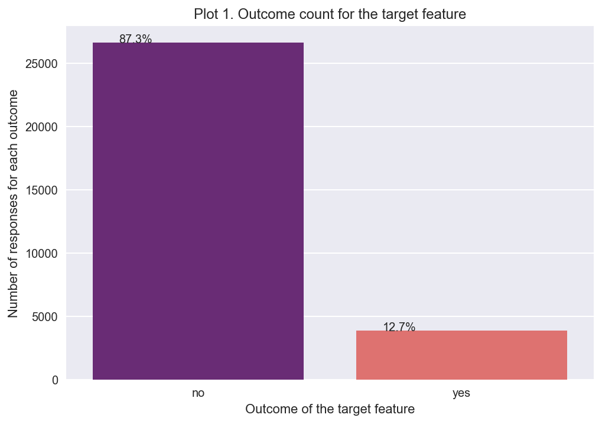

```python
# Marking the height of each bar

TD = clients['term_deposit']
Gross = len(TD)*1
figure_1 = sns.countplot(x='term_deposit', data =clients, palette = 'magma')
for p in figure_1.patches:
    figure_1.annotate('{:.1f}%'.format(100*p.get_height()/Gross), (p.get_x()+0.1, p.get_height()+5))

figure_1 = plt.title('Plot 1. Outcome count for the target feature')
plt.xlabel("Outcome of the target feature")
plt.ylabel("Number of responses for each outcome")
plt.show()
```

As we can see that the data is highly imbalanced which would have been expected as it is a marketing campaign, and coming from a marketing domain background I am able to say that these conversion rates hold good.

#### 1.2 Count Plot for Feature: Job

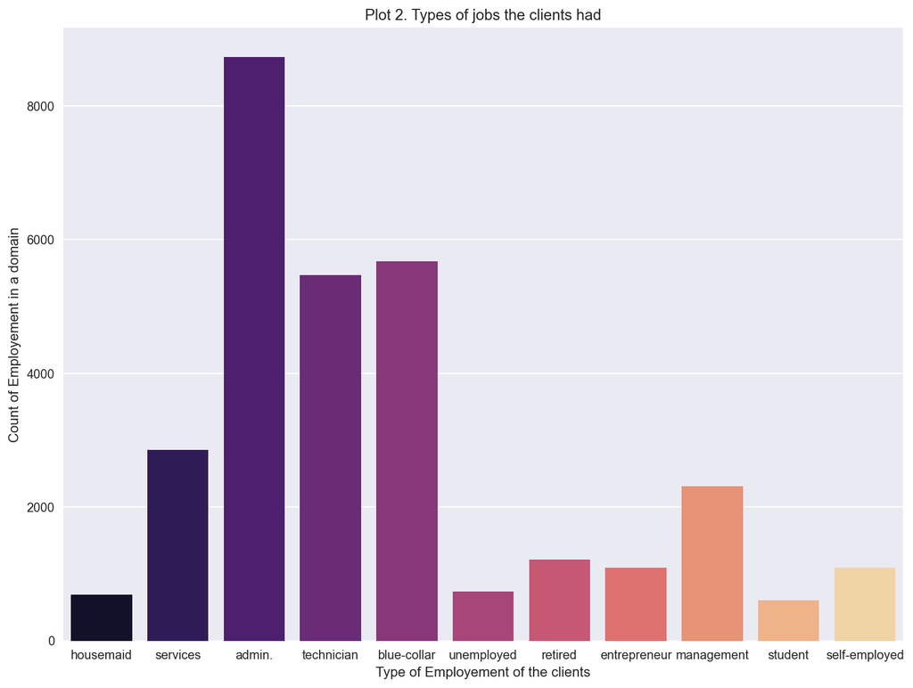

```python
# Setting figuresize of the output
plt.figure(figsize = (12,9))

# Using the seaborn package for plotting the countplot
sns.countplot(x='job', data=clients, palette ='magma')
plt.title('Plot 2. Types of jobs the clients had')
plt.xlabel("Type of Employement of the clients")
plt.ylabel("Count of Employement in a domain")

plt.show()
```

From the above plot we, can infer that most of the clients were employed as Administrators, technicians or were in the blue-collar domain. and Students, housemaids, and unemployed were least in number amongst the clients.

#### 1.3 Count Plot for Feature: Education

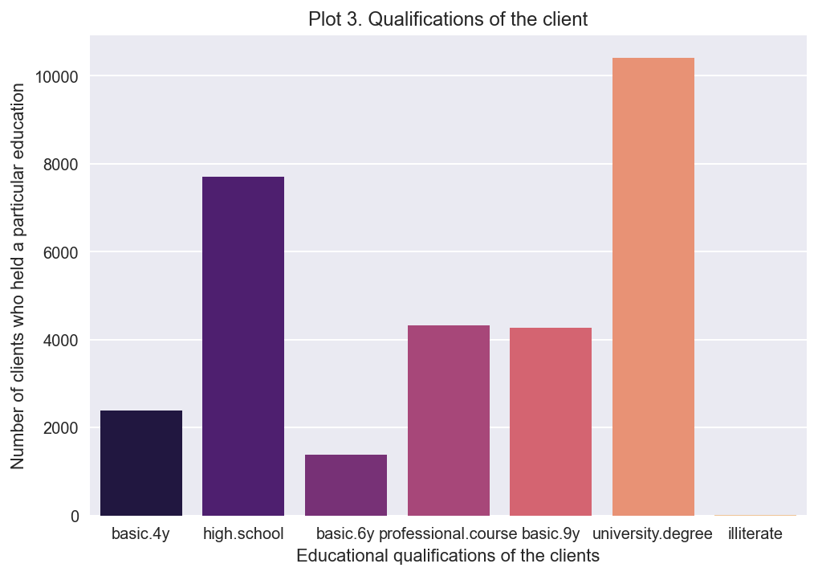

```python
# A count plot for education using the seaborn package

sns.countplot(x = 'education', data=clients, palette ='magma')
plt.title('Plot 3. Qualifications of the client')
plt.xlabel("Educational qualifications of the clients")
plt.ylabel("Number of clients who held a particular education")
plt.show()
```

We can observe that most of the clients of the bank held a university degree, and almost negligible amount were illiterate.

#### 1.4 Histogram for Feature: Age

`Age` being a numerical feature, a count plot would not be able to represent an accurate information about what most of the age-set is because of the abundance of values in the dataset. Hence, we will use a histogram to understand the dynamics of the `age` feature.

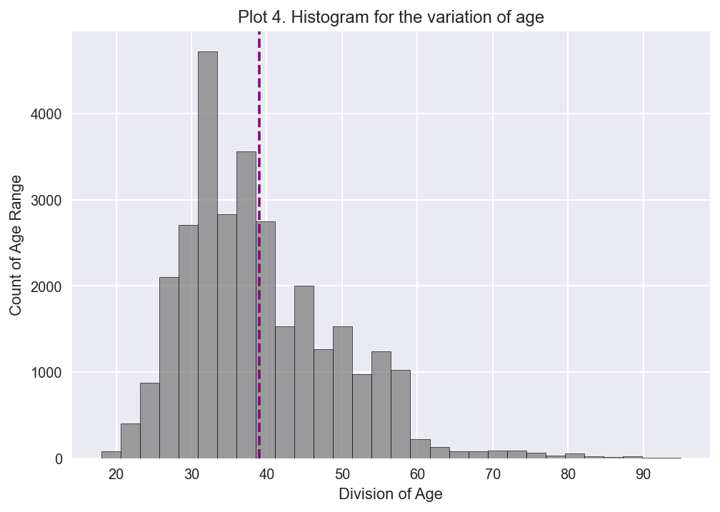

```python
# Histogram for Age

mean_of_age = clients['age'].mean()

sns.histplot(x='age', data = clients, bins= 30, color = 'grey')
plt.axvline(mean_of_age, color ='purple', linestyle ='--') # Marking the mean on the plot
plt.title ('Plot 4. Histogram for the variation of age')
plt.xlabel('Division of Age')
plt.ylabel('Count of Age Range')

plt.show()
```

As we can see that majority of our clients in the dataset belong between the ages of 30 and 40, and the histogram is skewed to the right i.e. a positive skew, we can say that the mean is being pulled towards the higher values. Considering this is a decently skewed data, and hence mean may not best define the central tendency of the plot.

#### 1.4.1 Box Plot for Feature: Age

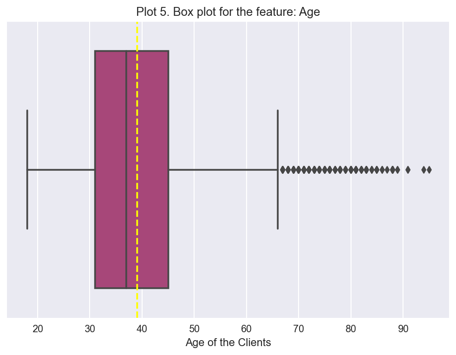

```python
# For better understanding the dynamics of Age

sns.boxplot(x = 'age', data = clients, palette = 'magma')
plt.axvline(mean_of_age, color ='yellow', linestyle ='--') # Marking the mean on the plot
plt.xlabel("Age of the Clients")
plt.title("Plot 5. Box plot for the feature: Age")
plt.show()
```

In terms of understanding of the above box plot we can say that there are a lot of values above the upper bound, that can be said to be as **'outliers'** , but considering a real world scenario, and that most of them could be legitimate clients, and could subscribe to a term deposit we can keep them in consideration.

#### 1.5 Distribution Plot for Feature: Campaign

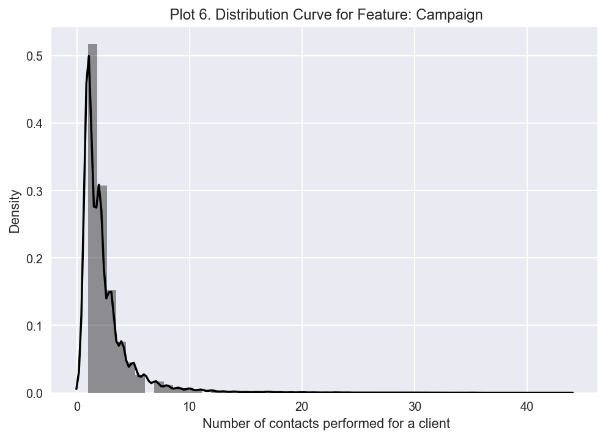

```python
# Distribution plot for Campaign

sns.distplot(clients ['campaign'], color = 'black')
plt.xlabel(" Number of contacts performed for a client")
plt.title(" Plot 6. Distribution Curve for Feature: Campaign")
plt.show()
```

On observation, we can see that most of the values in the `campaign` feature are between 0 and 10, i.e. a client was contacted anywhere between 0 and 10 times during the course of this campaign. We cannot treat the other values in this feature as outliers because in general practice some clients are contacted more than others.

#### 1.6 Distribution Plot for Feature: pdays

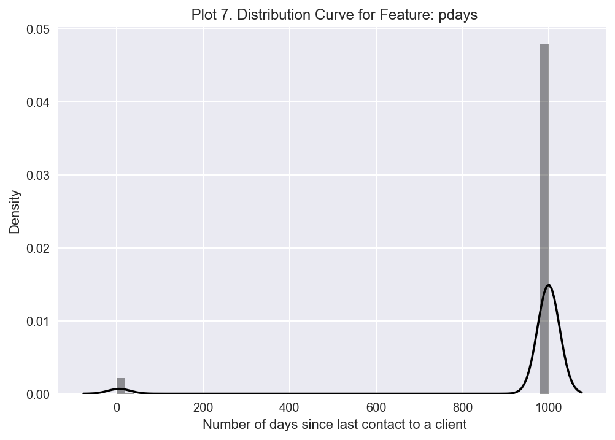

```python
# Distribution plot for pdays

sns.distplot(clients ['pdays'], color = 'black')
plt.xlabel(" Number of days since last contact to a client")
plt.title(" Plot 7. Distribution Curve for Feature: pdays")
plt.show()
```

This slightly unusual curve makes sense as the feature `pdays` includes a value `999` which means that the client was not previously contacted, and also which provides us the information that almost 96% of the clients were contacted for the first time in this campaign.

#### 1.7 Distribution Plot for Feature: previous

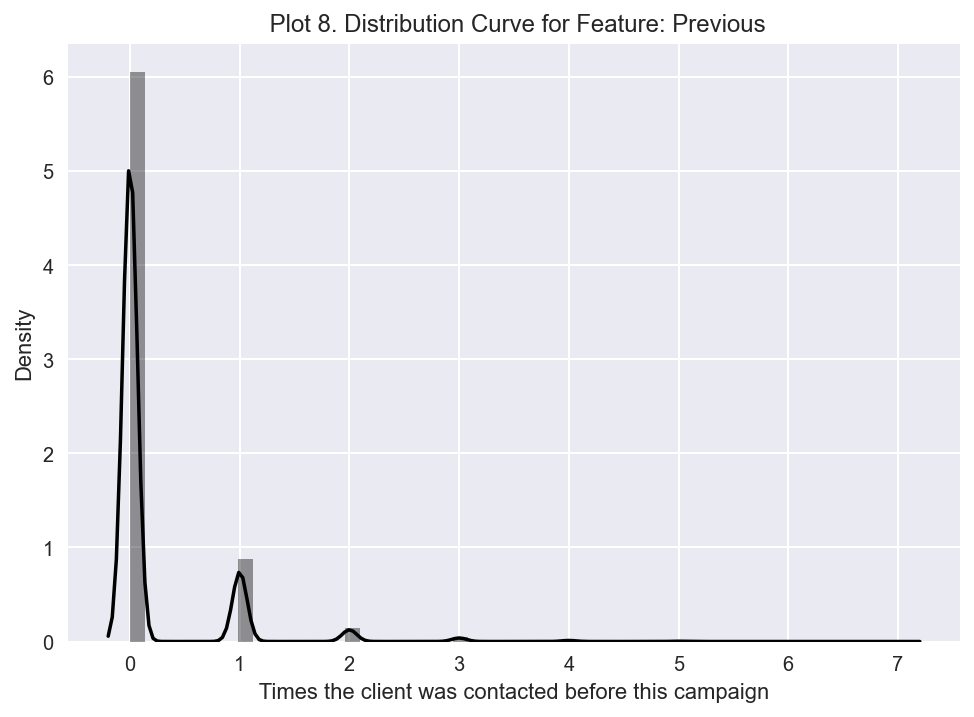

```python
# Distribution plot for previous

sns.distplot(clients ['previous'], color = 'black')
plt.xlabel(" Times the client was contacted before this campaign ")
plt.title(" Plot 8. Distribution Curve for Feature: Previous")
plt.show()
```

We can see that almost 85% of the clients were never contacted before.

### II. Two Variable Plots

#### 2.1 Distribution Plot for Feature: Term Deposit and Previous

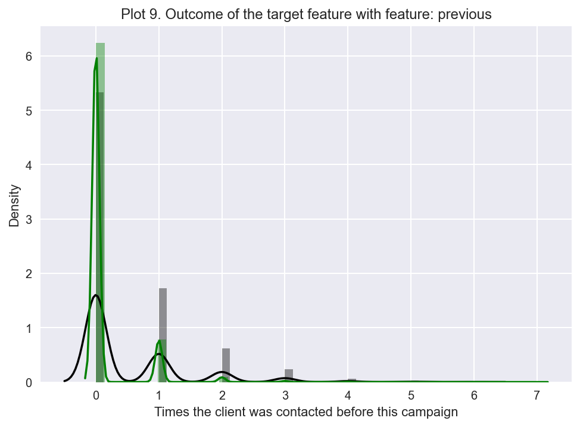

```python
# Dist. Plot for Term deposit and Previous

sns.distplot(clients[clients["term_deposit"] == "yes"] ["previous"], color ='black')
sns.distplot(clients[clients["term_deposit"] == "no"] ["previous"], color ='green')
plt.xlabel("Times the client was contacted before this campaign")
plt.title("Plot 9. Outcome of the target feature with feature: previous")
plt.show()
```

We can see that the rest of the data in `previous` has a variation between the outcome as well. So, we can continue to keep both these attributes for predicting the outcome feature.

#### 2.2 Scatter plot for Features: Consumer Price Index and Consumer Confidence Index

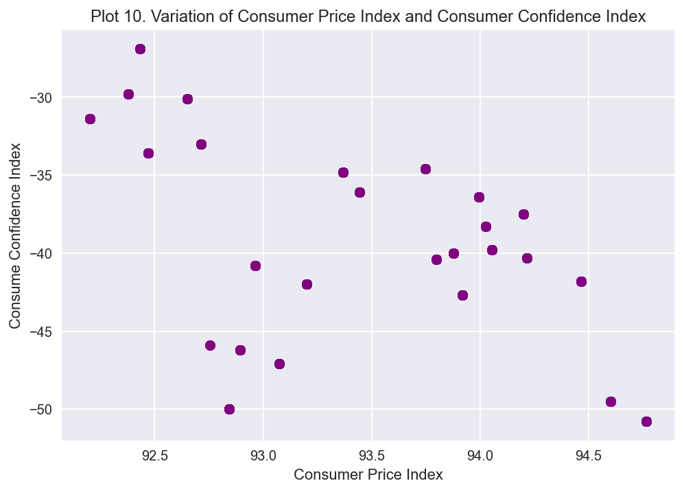

```python
# Scatter plot for Consumer Price Index and Consumer Confidence Index

plt.scatter(clients['cons_price_idx'], clients['cons_conf_idx'], color = 'purple')
plt.title("Plot 10. Variation of Consumer Price Index and Consumer Confidence Index")
plt.xlabel("Consumer Price Index")
plt.ylabel("Consume Confidence Index")
plt.show()
```

#### 2.3 Distribution plot for Features: Consumer Confidence Index and Term Deposit

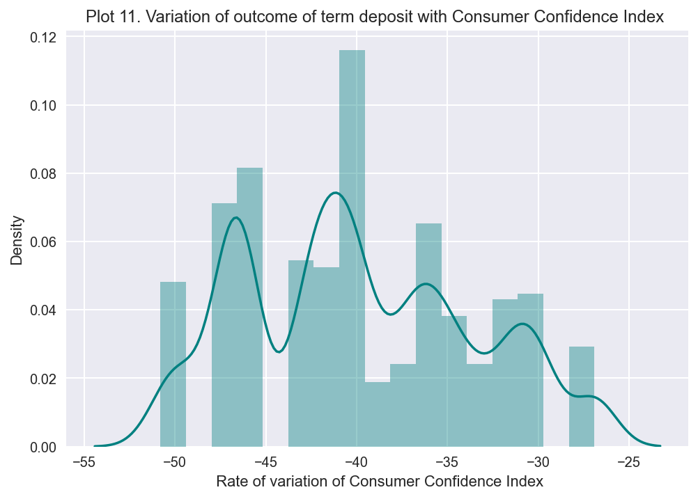

```python
sns.distplot(clients[clients["term_deposit"] == "yes"] ["cons_conf_idx"], color ='teal')
plt.title("Plot 11. Variation of outcome of term deposit with Consumer Confidence Index ")
plt.xlabel(" Rate of variation of Consumer Confidence Index")
plt.show()
```

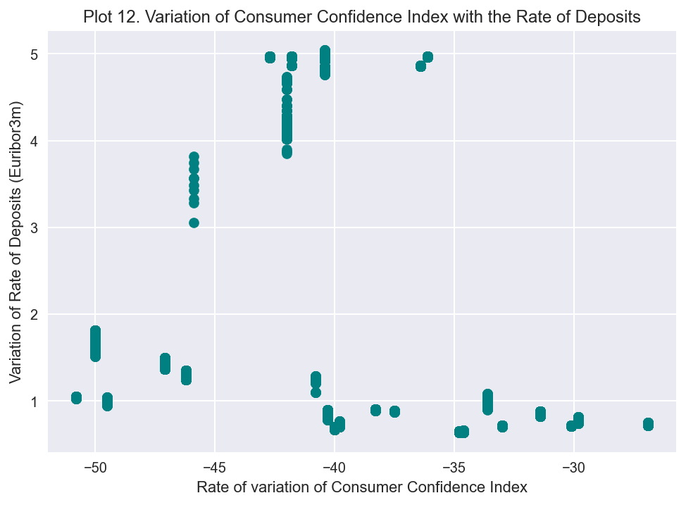

```python
# Continuation from the above plot

plt.scatter(clients.cons_conf_idx, clients.euribor3m, color = 'teal')
plt.title("Plot 12. Variation of Consumer Confidence Index with the Rate of Deposits")
plt.xlabel("Rate of variation of Consumer Confidence Index")
plt.ylabel("Variation of Rate of Deposits (Euribor3m)")
plt.show()
```

#### 2.4 Distribution plot for Features: Employement Variation Rate and Term Deposit

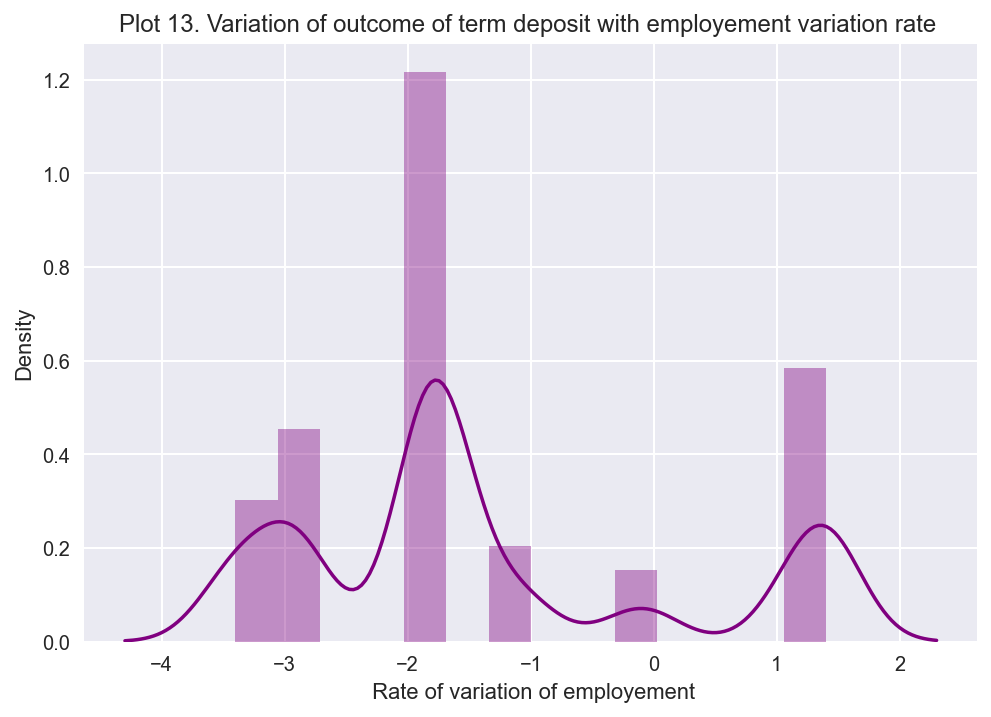

```python
# Variation of outcome of term_deposit with emp_var_rate

sns.distplot(clients[clients["term_deposit"] == "yes"] ["emp_var_rate"], color ='purple')
plt.title("Plot 13. Variation of outcome of term deposit with employement variation rate ")
plt.xlabel(" Rate of variation of employement")
plt.show()
```

From the above plot, we can observe that most of the clients who subscribed in favour of a term deposit did so when the employment variation decreased from the last quarter i.e. by -2. Which would make sense as employment goes down people start saving more.

#### 2.5 Count plot for Features: Job and Term Deposit

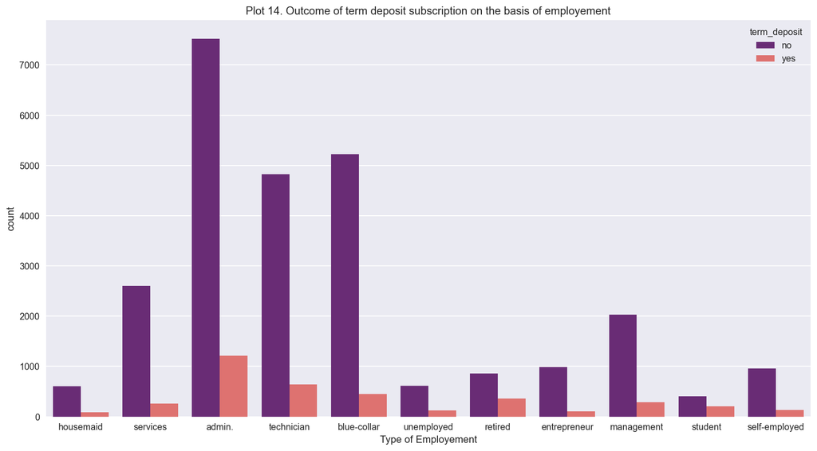

```python
# Employement wise result of subscription

plt.figure(figsize = (15,8))
sns.countplot(x = 'job', hue = 'term_deposit', data = clients, palette = 'magma')

plt.title("Plot 14. Outcome of term deposit subscription on the basis of employement")
plt.xlabel("Type of Employement")
plt.show()
```

From the count plot shown above, we can see that most of the clients were working as admins. There is no clear relationship between the type of job, and the outcome of `term_deposit`. It depends upon the number of people contacted, the more the better for the bank. We can plot similar graphs to check how many of each attribute subscribed for a `term_deposit`.

#### 2.5.1 Count plot(s) for other Categorical Features and Term Deposit

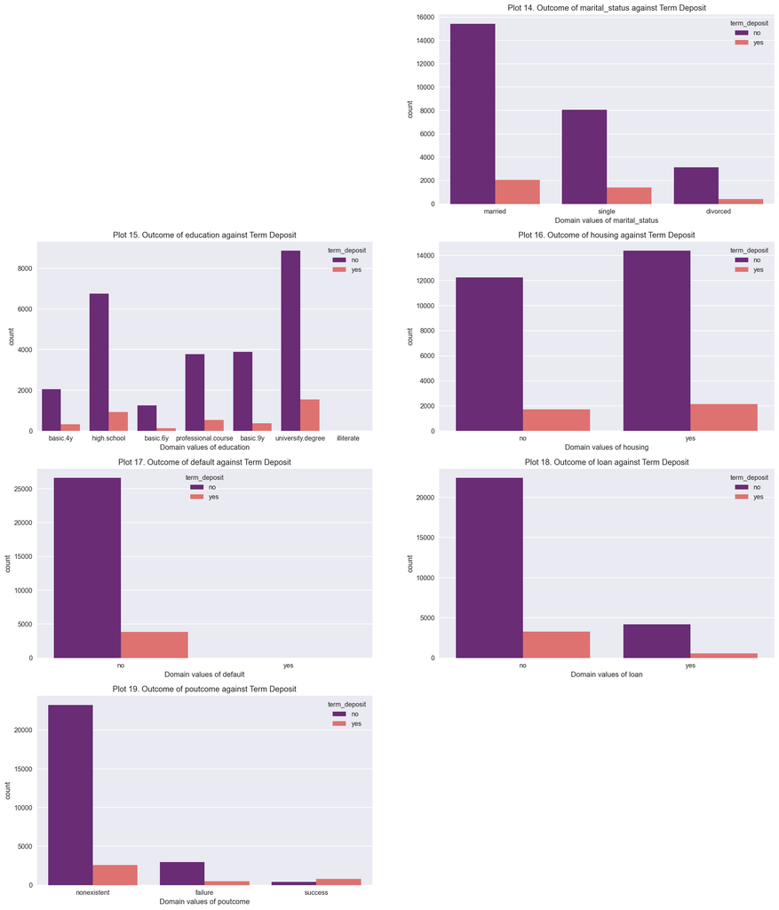

```python
# Plotting the outcome against different categorical features
cat_graphs = ['marital_status','education','housing','default','loan','poutcome']

plt.figure(figsize =(20,100))
plot_number = 14 #To continue the plot numbering in the plots below
for col in cat_graphs:
    axis = plt.subplot(16,2,plot_number)
    sns.countplot(x = col, hue = 'term_deposit', data = clients, palette = 'magma')
    plt.title('Plot '+ str(plot_number) +'. Outcome of '+ col +' against Term Deposit')
    plt.xlabel("Domain values of " + col)
    plot_number = plot_number +1

plt.show()
```

From the above plots we can infer the following:

1. Plot 14: Married clients were more in favour of attaining a term deposit account.
2. Plot 15: In terms of educational qualifications, university degree holders subscribed the most towards a term deposit.
3. Plot 16: Slightly more clients who had a housing loan, had also subscribed for term deposit account.
4. Plot 17: As expected, clients who had defaulted earlier on their loans did not take a term deposit account.
5. Plot 18: People who had a personal loan were, not even 50% of them applied for a term deposit account with the bank.
6. Plot 19: We can see that majority of the outcome from the `poutcome` feature were from the nonexistent value. Although, it is interesting to see that people who had already subscribed to a `term_deposit` reapplied for one (probably completed the process).

## III. Three Variable Plots

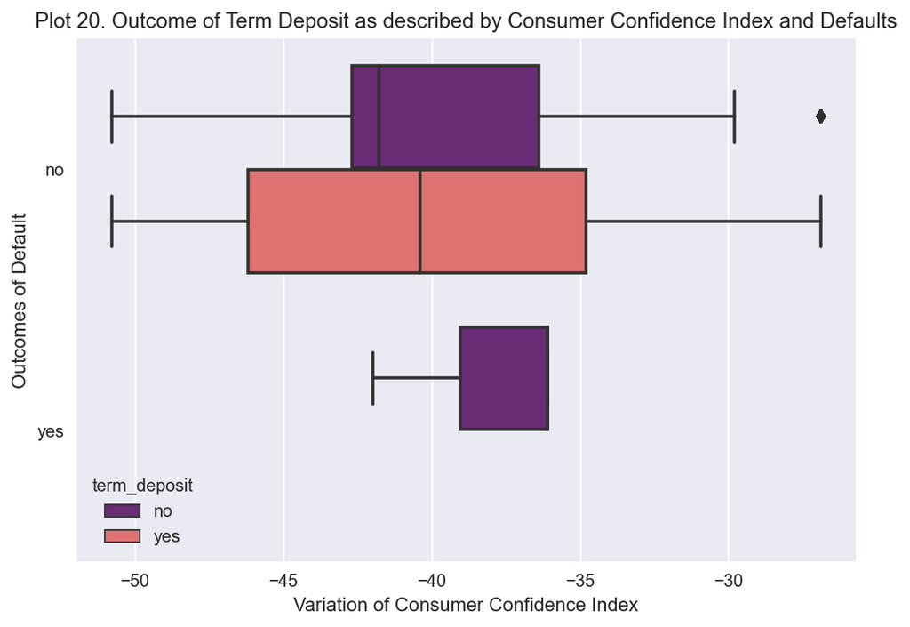

```python
# Box-plot for variation in age with default

sns.boxplot(x = 'cons_conf_idx', y = 'default', hue ='term_deposit', data = clients, palette ='magma')
plt.xlabel('Variation of Consumer Confidence Index')
plt.ylabel('Outcomes of Default')
plt.title('Plot 20. Outcome of Term Deposit as described by Consumer Confidence Index and Defaults')
plt.show()
```

#### 3.2 Scatter Plot of Term Deposit broken down by Number of Employed Clients and Consumer Confidence Index

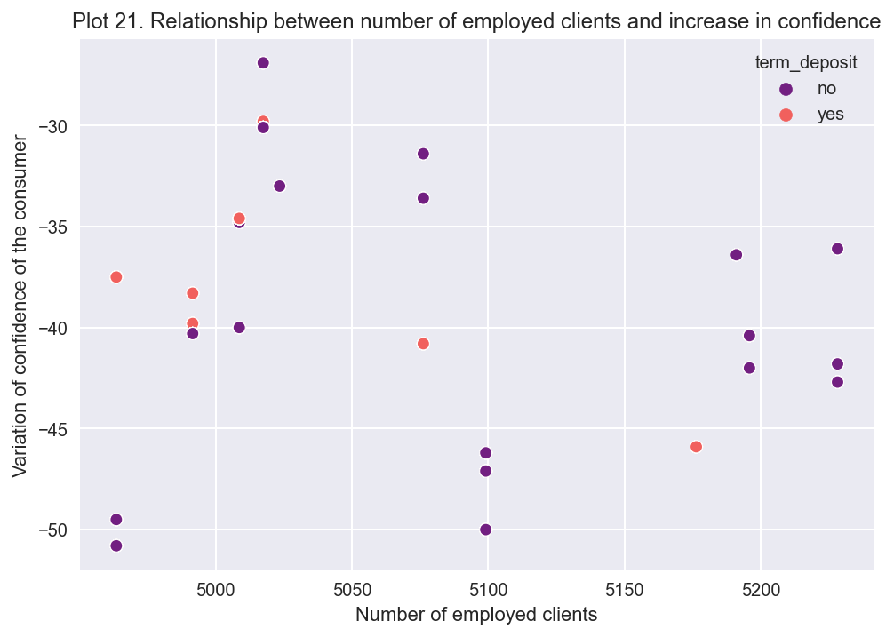

```python
# Scatter Plot describing the relation between nr_employed and cons_conf_idx and final outcome

sns.scatterplot(x='nr_employed',y='cons_conf_idx', hue = 'term_deposit', data=clients, palette ='magma')
plt.xlabel('Number of employed clients')
plt.ylabel('Variation of confidence of the consumer')
plt.title('Plot 21. Relationship between number of employed clients and increase in confidence')
plt.show()
```

## Summary and Conclusion

In the context of a bank, being able to know beforehand what customers are likely to subscribe for a term deposit account can be immensely beneficial. From how marketing has changed over the years from cold calls to being able to bid so that an advertisement is shown to a customer, technology has been the means to-do-so. With every improvement, an organisation is trying to secure customers for itself.

In this particular case-study, it contains data from the year 2008 to 2010, the period when the housing market crashed. Considering that context, for banks at that time it would have become imperative to secure clients for long term deposits.

The goals of this project are to predict what type of customers are like to subscribe to a term deposit with a bank using the bank marketing dataset of a Portuguese Bank, and that what descriptive features are most suitable for doing so.

This report pertains to the phase-1 of this project, and tasks such as data cleaning and preprocessing were performed along with data exploration and visualizations. In the Data Wrangling process, we:

1. First, we dropped all the missing values, as such there were not any missing values specified via NA or NaN but marked as `unknown` in attributes `job`,`education`,`marital_status`, `housing`,`loan`, and `default`, and we dropped them citing their contribution was less as compared to the rest of the dataset.
2. We then moved-on to remove all (10) the duplicate observations as they would not have any contribution for the predictive analysis process.
3. Further, we dropped the `duration` attribute as the value of this cannot be known before a call is placed, although the attribute would have had an effect on the outcome of the target feature, it does not provide a benefit for predicting the outcome, as this field would depend upon the data from the customer care executive or the marketing team. This model intends to predict without the use of the `duration` feature.
4. There were not actually any wrong values but there were two observations with age as 17, which we dropped considering the client is yet not an adult, and would not be able to subscribe to a term deposit account.
5. Columns such as `marital` and `y` were renamed to `marital_status` and `term_deposit`. There were attributes with a `.` (period) in them, and that was replaced by an `_` (underscore).

After the Data Cleaning and Preprocessing process, we also plotted several visualizations in order to better understand the data at hand. The visualizations were divided into one-variable, two-variable, and three-variable plots.

## References

1. Moro S., Cortez P., & Rita P. (2014). A data-driven appraoch to the success of bank telemarketing. *Decision Support Systems, 62*, 22-31,. http://dx.doi.org/10.1016/j.dss.2014.03.001
2. UCI Machine Learning Repository. (2014). *Bank Marketing Data Set*. https://archive.ics.uci.edu/ml/datasets/Bank+Marketing#
3. James Chen. Investopedia. (2022). *Term Deposit*. Investopedia. https://www.investopedia.com/terms/t/termdeposit.asp
4. Jason Fernando. Investopedia. (2022). *Consumer Price Index (CPI)*. Investopedia. https://www.investopedia.com/terms/c/consumerpriceindex.asp
5. Akhilesh Ganti. Investopedia. (2022). *Consumer Confidence Index (CCI)*. Investopedia. https://www.investopedia.com/terms/c/cci.asp